# Capstone project of the Coursera course - Bayesian statistics: techniques and models

Andrei Keino

April 12, 2019

This is the capstone project of the Coursera course - Bayesian statistics: techniques and models https://www.coursera.org/learn/mcmc-bayesian-statistics/. The aim of the project is: select a research problem and accompanying data set that interest you. In selecting a data set, use publicly available data or data that you own (a few websites providing publicly available data are listed below). If you do not personally own the data, be sure to respect copyright laws and do not distribute the data without permission of the owner. If the data are owned by your employer or are otherwise sensitive (e.g., contain protected information), be sure that none of your analyses violate non-disclosure agreements or otherwise compromise anonymity. Responsible, ethical data handling is critical in science, public service, and business.

## Description of the data to be analyzed.

The analyzed data are contained in publicly available data set **EuStockMarkets**. This data set contains the daily closing prices of major European stock indices: Germany DAX (Ibis), Switzerland SMI, France CAC, and UK FTSE, for 1991-1998. The data are sampled in business time, i.e., weekends and holidays are omitted.

#### There is the trading algorithm known as **pairs trading algorithm**.

This is a form of mean reversion algorithm that has a distinct advantage of always being hedged against market movements. Pairs trading is a classic example of a strategy based on mathematical analysis. The principle is as follows. Let’s say you have a pair of securities X and Y that have some underlying economic link. An example might be two companies that manufacture the same product, or two companies in one supply chain. If we can model this economic link with a mathematical model, we can make trades on it. More on this can be found here: https://www.quantopian.com/lectures/introduction-to-pairs-trading

## The aim of the analysis is to asses the linear relationship for some cointegrated pair with the help of the MCMC.

## The summary of data:

```
##       DAX            SMI            CAC            FTSE
##  Min.   :1402   Min.   :1587   Min.   :1611   Min.   :2281
##  1st Qu.:1744   1st Qu.:2166   1st Qu.:1875   1st Qu.:2843
##  Median :2141   Median :2796   Median :1992   Median :3247
##  Mean   :2531   Mean   :3376   Mean   :2228   Mean   :3566
##  3rd Qu.:2722   3rd Qu.:3812   3rd Qu.:2274   3rd Qu.:3994
##  Max.   :6186   Max.   :8412   Max.   :4388   Max.   :6179
```

## The plot of data:

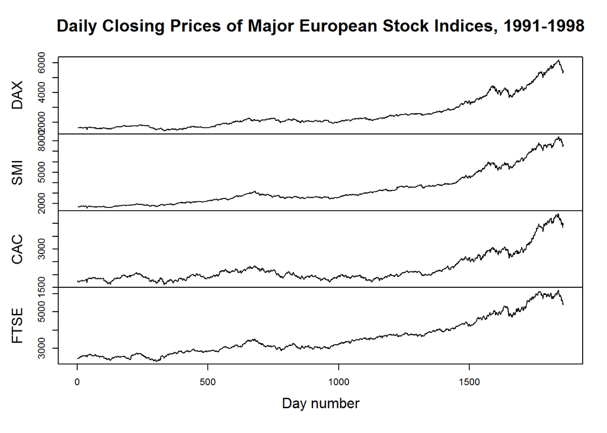

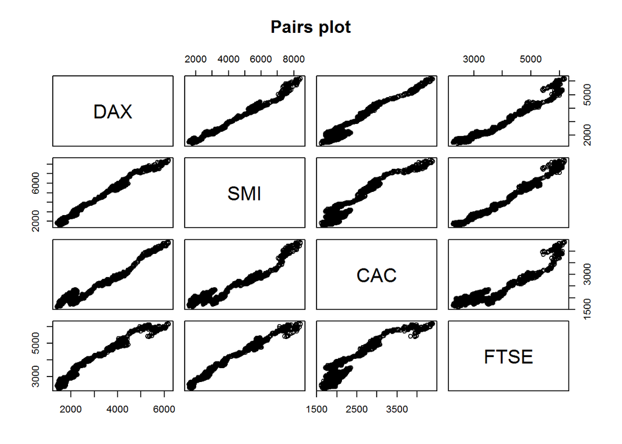

As it can be seen from the pairs plot, the best cointegrated pairs are DAX:SMI and FTSE:SMI or maybe the reversed ones: SMI:DAX and SMI:FTSE.

## Cointegration tests.

If we fit the linear regression to our potentially cointegrated pairs, we will will get the residuals and we’ll be able to run the cointegration Augmented Dickey-Fuller Test.

```
## [1] "*****     ADF test for DAX:SMI"
```

```
##
## Call:
## lm(formula = DAX ~ SMI, data = df)
##
## Residuals:
##     Min      1Q  Median      3Q     Max
## -285.75 -106.88  -20.15  104.20  603.45
##
## Coefficients:
##              Estimate Std. Error t value Pr(>|t|)
## (Intercept) 3.478e+02  7.558e+00   46.02   <2e-16 ***
## SMI         6.465e-01  2.008e-03  321.91   <2e-16 ***
## ---
## Signif. codes:  0 '***' 0.001 '**' 0.01 '*' 0.05 '.' 0.1 ' ' 1
##
## Residual standard error: 144 on 1858 degrees of freedom
## Multiple R-squared:  0.9824, Adjusted R-squared:  0.9824
## F-statistic: 1.036e+05 on 1 and 1858 DF,  p-value: < 2.2e-16
```

```
##
##  Augmented Dickey-Fuller Test
##
## data:  comb1$residuals
## Dickey-Fuller = -3.2852, Lag order = 1, p-value = 0.07322
## alternative hypothesis: stationary
```

```
## [1] "*****     ADF test for SMI:DAX"
```

[output not shown]

[output not shown]

```
## [1] "*****     ADF test for FTSE:SMI"
```

```
##
## Call:
## lm(formula = FTSE ~ SMI, data = df)
##
## Residuals:
##     Min      1Q  Median      3Q     Max
## -616.86  -79.83   -2.71   96.31  368.56
##
## Coefficients:
##              Estimate Std. Error t value Pr(>|t|)
## (Intercept) 1.603e+03  7.245e+00   221.2   <2e-16 ***
## SMI         5.814e-01  1.925e-03   302.0   <2e-16 ***
## ---
## Signif. codes:  0 '***' 0.001 '**' 0.01 '*' 0.05 '.' 0.1 ' ' 1
##
## Residual standard error: 138 on 1858 degrees of freedom
## Multiple R-squared:   0.98,  Adjusted R-squared:   0.98
## F-statistic: 9.122e+04 on 1 and 1858 DF,  p-value: < 2.2e-16
```

```
##
##  Augmented Dickey-Fuller Test
##
## data:  comb3$residuals
## Dickey-Fuller = -3.0321, Lag order = 1, p-value = 0.1414
## alternative hypothesis: stationary
```

```
## [1] "*****     ADF test for SMI:FTSE"
```

```
##
## Call:
## lm(formula = SMI ~ FTSE, data = df)
##
## Residuals:
##     Min      1Q  Median      3Q     Max
## -573.77 -156.56    1.52  128.31 1135.47
##
## Coefficients:
##               Estimate Std. Error t value Pr(>|t|)
## (Intercept) -2.634e+03  2.063e+01  -127.7   <2e-16 ***
## FTSE         1.686e+00  5.581e-03   302.0   <2e-16 ***
## ---
## Signif. codes:  0 '***' 0.001 '**' 0.01 '*' 0.05 '.' 0.1 ' ' 1
##
## Residual standard error: 235 on 1858 degrees of freedom
## Multiple R-squared:   0.98,  Adjusted R-squared:   0.98
## F-statistic: 9.122e+04 on 1 and 1858 DF,  p-value: < 2.2e-16
```

```
##
##  Augmented Dickey-Fuller Test
##
## data:  comb4$residuals
## Dickey-Fuller = -2.8434, Lag order = 1, p-value = 0.2213
## alternative hypothesis: stationary
```

##### As it can be seen from the results of Augmented Dickey-Fuller Test, the **best** cointegrated pair is the **DAX ~ SMI**, because of smaller p - value and smaller ADF test statistics. The **worst** cointegrated pair is the **SMI ~ FTSE** because of the largest p - value. Nevertheless, the p - value even for the DAX ~ SMI pair is not very good, because it si more than 5% (ordinary level of the stationary hypothesis rejection).

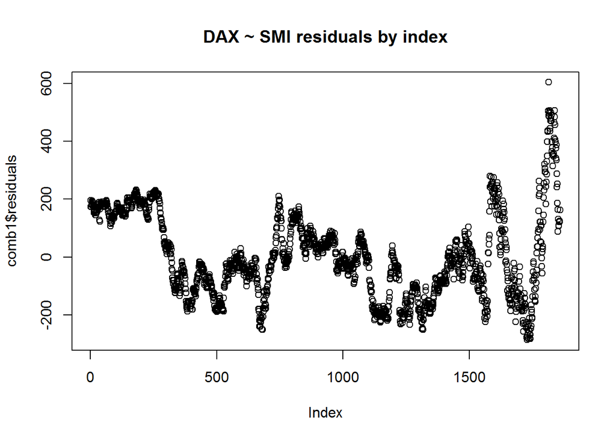

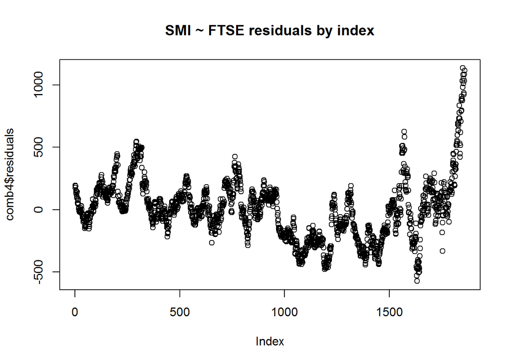

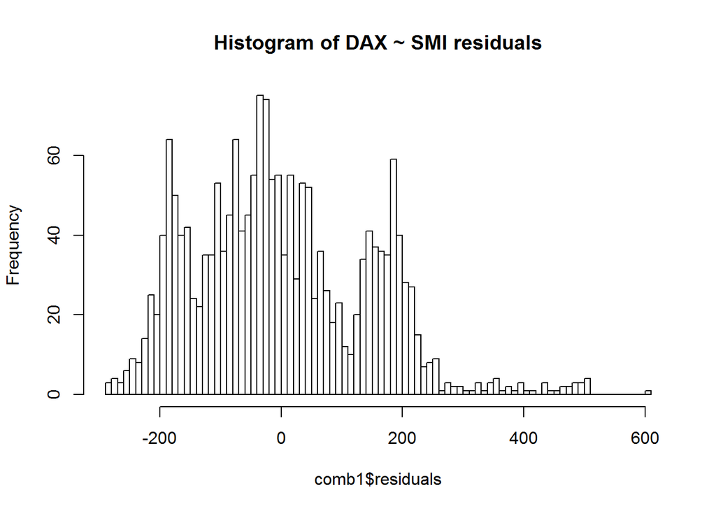

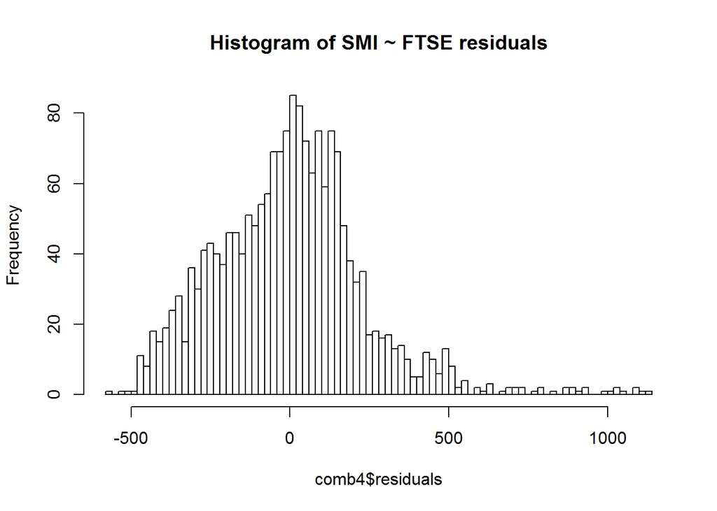

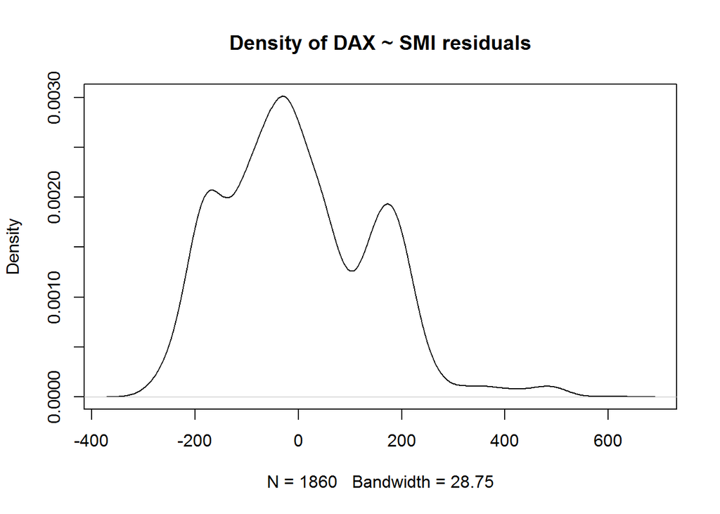

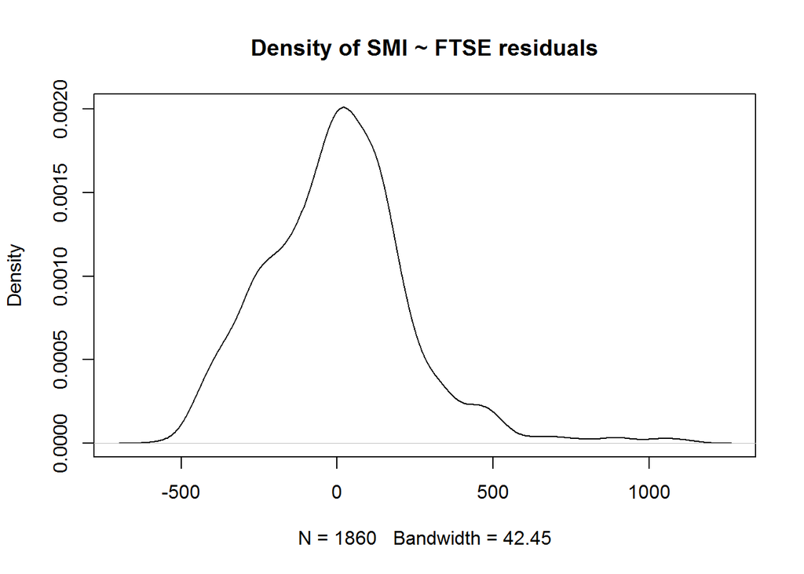

#### The residuals for linear regression of DAX ~ SMI seems to have a complex stucture, so they can be modeled as a muxture of three distributions. Also, it seems what the residuals for the linear models are not stationary.

## Evaulation of the DAX ~ SMI linear model with the MCMC:

Now the linear model $DAX = b_1 + b_2 SMI$ will be fitted with the help of MCMC. Prior distribution for the coefficients $b_i$ will be modeled as $N(0, 10^{6})$. The prior distribution for $\sigma^2$ will be modeled as Inverse Gamma distribution - $IG(5/2, 25)$.

```
##              b[1]       b[2]          sig
## Lag 0  1.00000000 1.00000000  1.000000000
## Lag 1  0.79455319 0.79495628  0.001152512
## Lag 5  0.31550827 0.31355915  0.002176493
## Lag 10 0.07535164 0.07839791 -0.004119108
## Lag 50 0.03152161 0.02912290  0.007161123
```

```
## Potential scale reduction factors:
##
##      Point est. Upper C.I.
## b[1]          1          1
## b[2]          1          1
## sig           1          1
##
## Multivariate psrf
##
## 1
```

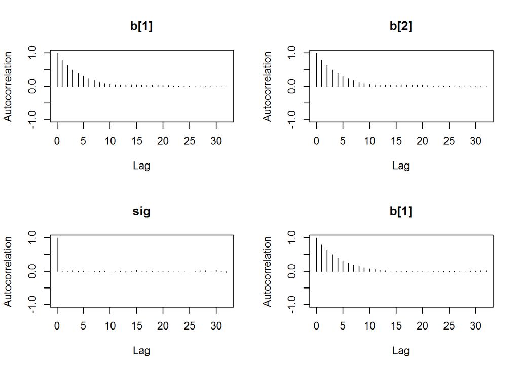

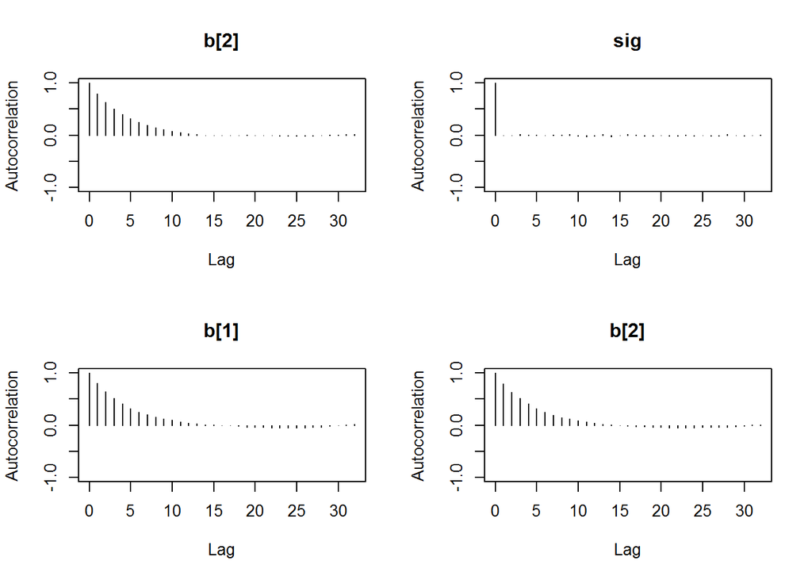

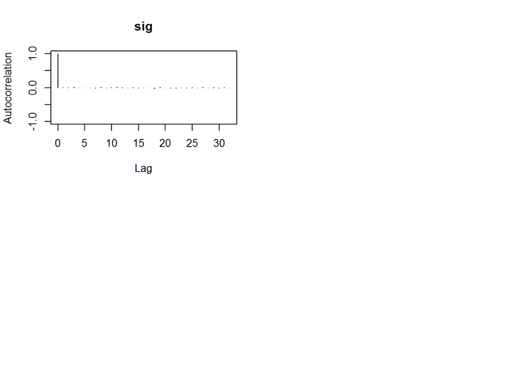

```
##      b[1]      b[2]       sig
##  1717.103  1740.385 15000.000
```

```
## [1] "MCMC diagnostics and posterior distributions:"
```

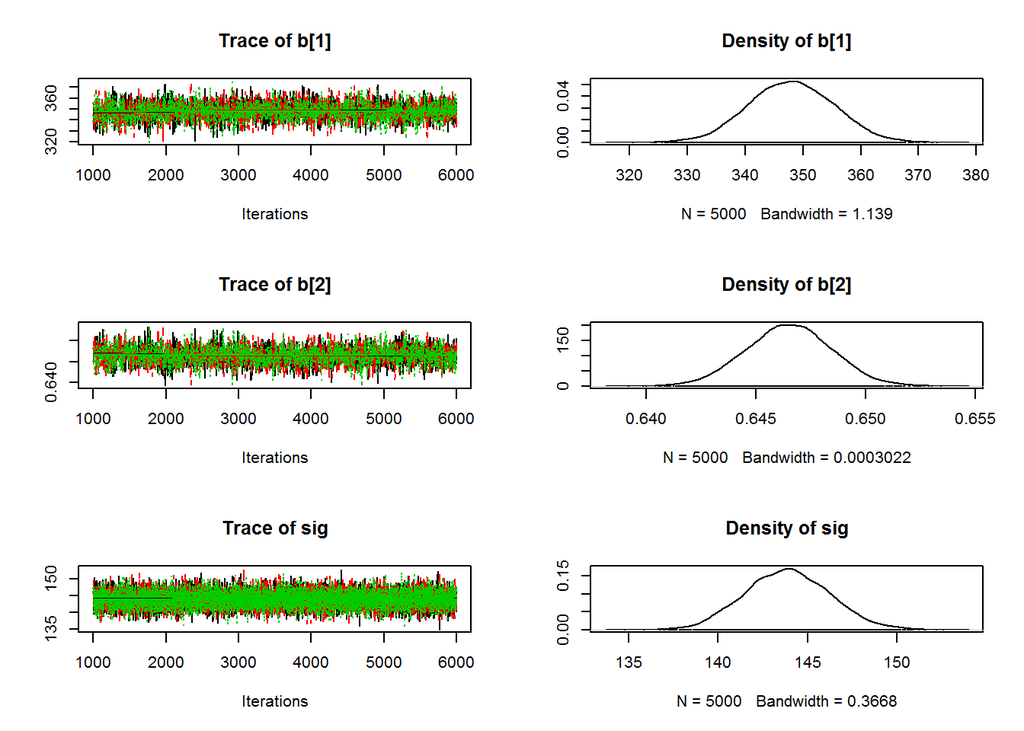

```
## [1] "DAX ~ SMI linear model with the MCMC summary:"
```

```
##
## Iterations = 1001:6000
## Thinning interval = 1
## Number of chains = 3
## Sample size per chain = 5000
##
## 1. Empirical mean and standard deviation for each variable,
##    plus standard error of the mean:
##
##          Mean       SD  Naive SE Time-series SE
## b[1] 347.9313 7.352919 6.004e-02      1.776e-01
## b[2]   0.6465 0.001951 1.593e-05      4.676e-05
## sig  143.8713 2.367513 1.933e-02      1.933e-02
##
## 2. Quantiles for each variable:
##
##          2.5%      25%      50%      75%    97.5%
## b[1] 333.6149 342.9225 347.9180 352.9655 362.2439
## b[2]   0.6427   0.6452   0.6465   0.6478   0.6503
## sig  139.3781 142.2463 143.8550 145.4938 148.6106
```

```
## [1] "DAX ~ SMI linear model summary:"
```

```
##
## Call:
## lm(formula = DAX ~ SMI, data = df)
##
## Residuals:
##     Min      1Q  Median      3Q     Max
## -285.75 -106.88  -20.15  104.20  603.45
##
## Coefficients:
##              Estimate Std. Error t value Pr(>|t|)
## (Intercept) 3.478e+02  7.558e+00   46.02   <2e-16 ***
## SMI         6.465e-01  2.008e-03  321.91   <2e-16 ***
## ---
## Signif. codes:  0 '***' 0.001 '**' 0.01 '*' 0.05 '.' 0.1 ' ' 1
##
## Residual standard error: 144 on 1858 degrees of freedom
## Multiple R-squared:  0.9824, Adjusted R-squared:  0.9824
## F-statistic: 1.036e+05 on 1 and 1858 DF,  p-value: < 2.2e-16
```